# practical machine learning (DSCI 6601) assignment 1

## NWUDO CHIKAEZE FIDELIS JUNIOR, STUDENT No: 202290064

#### QUESTION 1: Take a screenshot of your computer, showing a working Python setup (either a Python Notebook environment or ability to run Python from a command shell (e.g. Anaconda). Also display system information sufficient to uniquely identify your machine (and make sure the information is legible).

```python
import os
cwd = os.getcwd()
cwd
```

```
'C:\\Users\\HP PAVILION'
```

[figure not shown]

#### QUESTION 2: Write some Python code that can load in a .CSV file. Load in the Heart.csv file from the “Introduction to Statistical Learning” website (https://www.statlearning.com/s/Heart.csv). Load the data into a numpy array and have the code print the column headings in the dataset and the 25th data row/observation contained in the file.

```python
import numpy as np
import pandas as pd
import matplotlib.pyplot as plt
```

```python
df=pd.read_csv("Heart.csv") ## importing a csv file
df
```

|  | Unnamed: 0 | Age | Sex | ChestPain | RestBP | Chol | Fbs | RestECG | MaxHR | ExAng | Oldpeak | Slope | Ca | Thal | AHD |
| --- | --- | --- | --- | --- | --- | --- | --- | --- | --- | --- | --- | --- | --- | --- | --- |
| 0 | 1 | 63 | 1 | typical | 145 | 233 | 1 | 2 | 150 | 0 | 2.3 | 3 | 0.0 | fixed | No |
| 1 | 2 | 67 | 1 | asymptomatic | 160 | 286 | 0 | 2 | 108 | 1 | 1.5 | 2 | 3.0 | normal | Yes |
| 2 | 3 | 67 | 1 | asymptomatic | 120 | 229 | 0 | 2 | 129 | 1 | 2.6 | 2 | 2.0 | reversable | Yes |
| 3 | 4 | 37 | 1 | nonanginal | 130 | 250 | 0 | 0 | 187 | 0 | 3.5 | 3 | 0.0 | normal | No |
| 4 | 5 | 41 | 0 | nontypical | 130 | 204 | 0 | 2 | 172 | 0 | 1.4 | 1 | 0.0 | normal | No |
| ... | ... | ... | ... | ... | ... | ... | ... | ... | ... | ... | ... | ... | ... | ... | ... |
| 298 | 299 | 45 | 1 | typical | 110 | 264 | 0 | 0 | 132 | 0 | 1.2 | 2 | 0.0 | reversable | Yes |
| 299 | 300 | 68 | 1 | asymptomatic | 144 | 193 | 1 | 0 | 141 | 0 | 3.4 | 2 | 2.0 | reversable | Yes |
| 300 | 301 | 57 | 1 | asymptomatic | 130 | 131 | 0 | 0 | 115 | 1 | 1.2 | 2 | 1.0 | reversable | Yes |
| 301 | 302 | 57 | 0 | nontypical | 130 | 236 | 0 | 2 | 174 | 0 | 0.0 | 2 | 1.0 | normal | Yes |
| 302 | 303 | 38 | 1 | nonanginal | 138 | 175 | 0 | 0 | 173 | 0 | 0.0 | 1 | NaN | normal | No |

303 rows × 15 columns

```python
a=df.to_numpy() ##converting a panda Dataframe to a numpy data
print(a)
```

```
[[1 63 1 ... 0.0 'fixed' 'No']
 [2 67 1 ... 3.0 'normal' 'Yes']
 [3 67 1 ... 2.0 'reversable' 'Yes']
 ...
 [301 57 1 ... 1.0 'reversable' 'Yes']
 [302 57 0 ... 1.0 'normal' 'Yes']
 [303 38 1 ... nan 'normal' 'No']]
```

```python
print(df.columns) ## print the columns nd the 25th row
print(a[24])
```

```
Index(['Unnamed: 0', 'Age', 'Sex', 'ChestPain', 'RestBP', 'Chol', 'Fbs',
       'RestECG', 'MaxHR', 'ExAng', 'Oldpeak', 'Slope', 'Ca', 'Thal', 'AHD'],
      dtype='object')
[25 60 1 'asymptomatic' 130 206 0 2 132 1 2.4 2 2.0 'reversable' 'Yes']
```

#### QUESTION 3: In this exercise, you will plot some data using the matplotlib library. Create two side-by-side plots. In one, plot the Age column against the MaxHR column in the dataset. In the other, plot the Age column against the RestBP. Set an appropriate label on the overall plot figure as well as the individual sub-plots. Finally, create a third stand-alone plot that contains both of the above plots in one, making sure that the MaxHR and RestBP plots can be clearly differentiated by changing the plot type and creating a plot legend.

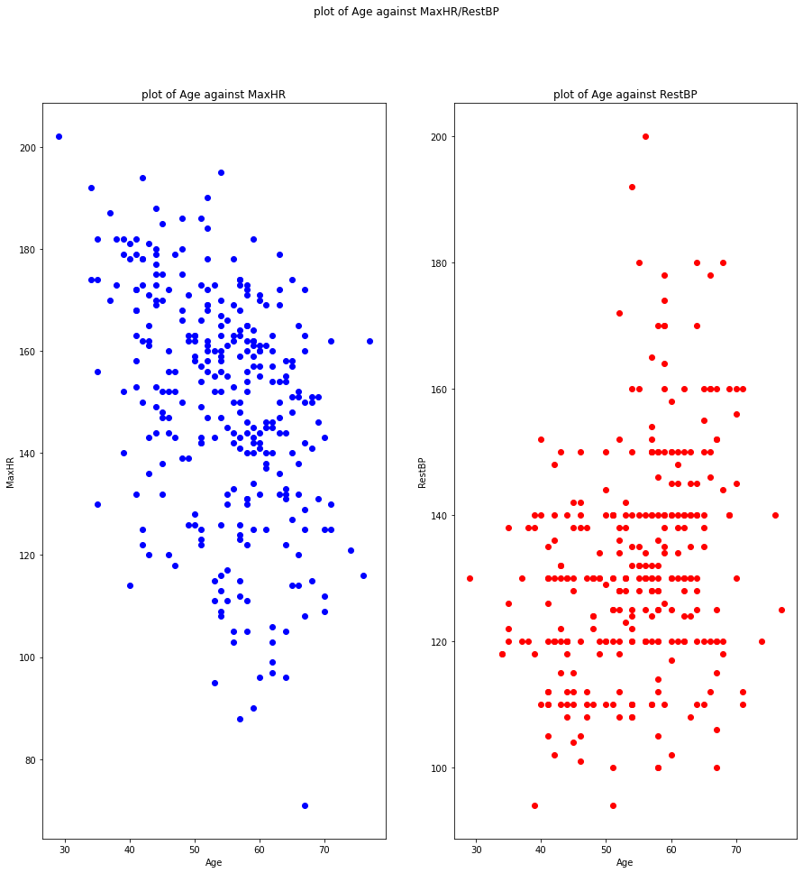

```python
fig=plt.figure(figsize=(15,15))

plt.subplot(121)
plt.scatter(df['Age'],df['MaxHR'],color='blue')
plt.xlabel('Age')
plt.ylabel('MaxHR')
plt.title('plot of Age against MaxHR')

plt.subplot(122)
plt.scatter(df['Age'],df['RestBP'],color='red')
plt.xlabel('Age')
plt.ylabel('RestBP')
plt.title('plot of Age against RestBP')

fig.suptitle('plot of Age against MaxHR/RestBP ')
```

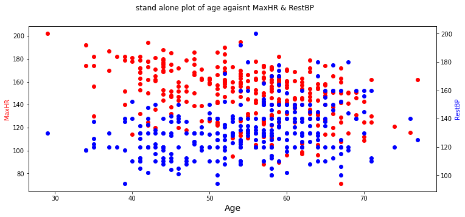

```python
fig,ax=plt.subplots(num=2, figsize=(12,5))
ax.scatter(df['Age'],df['MaxHR'],marker='o',color='red', label='MaxHR')
ax.set_xlabel('Age',fontsize=14)
ax.set_ylabel('MaxHR',color='red',fontsize=10)
ax2=ax.twinx()
ax2.scatter(df['Age'],df['RestBP'],marker='o',color='blue', label = 'RestBP')
ax2.set_ylabel('RestBP', color='blue',fontsize=10)
plt.suptitle('stand alone plot of age agaisnt MaxHR & RestBP ')
plt.show()
```

##### QUESTION 4:Use Sci-kit learn to create a simple linear regression model from the same Heart dataset. Creator a predictor that can predict the MaxHR using all the other columns. First partition the data into a training and a test set. Try at least 3 different partitions based on training:test ratios of (1) 50:50, (2) 75:25 and (3) 90:10. For each partition, calculate the training error and the testing error (use simple error function based on mean error) after fitting the LinearRegression model. Provide some explanation of what is happening in terms of any changes in the training vs. testing errors across the various ratio cases.

```python
df=df.drop(columns=["ChestPain","Thal","AHD"])
df
```

|  | Unnamed: 0 | Age | Sex | RestBP | Chol | Fbs | RestECG | MaxHR | ExAng | Oldpeak | Slope | Ca |
| --- | --- | --- | --- | --- | --- | --- | --- | --- | --- | --- | --- | --- |
| 0 | 1 | 63 | 1 | 145 | 233 | 1 | 2 | 150 | 0 | 2.3 | 3 | 0.0 |
| 1 | 2 | 67 | 1 | 160 | 286 | 0 | 2 | 108 | 1 | 1.5 | 2 | 3.0 |
| 2 | 3 | 67 | 1 | 120 | 229 | 0 | 2 | 129 | 1 | 2.6 | 2 | 2.0 |
| 3 | 4 | 37 | 1 | 130 | 250 | 0 | 0 | 187 | 0 | 3.5 | 3 | 0.0 |
| 4 | 5 | 41 | 0 | 130 | 204 | 0 | 2 | 172 | 0 | 1.4 | 1 | 0.0 |
| ... | ... | ... | ... | ... | ... | ... | ... | ... | ... | ... | ... | ... |
| 298 | 299 | 45 | 1 | 110 | 264 | 0 | 0 | 132 | 0 | 1.2 | 2 | 0.0 |
| 299 | 300 | 68 | 1 | 144 | 193 | 1 | 0 | 141 | 0 | 3.4 | 2 | 2.0 |
| 300 | 301 | 57 | 1 | 130 | 131 | 0 | 0 | 115 | 1 | 1.2 | 2 | 1.0 |
| 301 | 302 | 57 | 0 | 130 | 236 | 0 | 2 | 174 | 0 | 0.0 | 2 | 1.0 |
| 302 | 303 | 38 | 1 | 138 | 175 | 0 | 0 | 173 | 0 | 0.0 | 1 | NaN |

303 rows × 12 columns

```python
df=df.dropna()
df
```

|  | Unnamed: 0 | Age | Sex | RestBP | Chol | Fbs | RestECG | MaxHR | ExAng | Oldpeak | Slope | Ca |
| --- | --- | --- | --- | --- | --- | --- | --- | --- | --- | --- | --- | --- |
| 0 | 1 | 63 | 1 | 145 | 233 | 1 | 2 | 150 | 0 | 2.3 | 3 | 0.0 |
| 1 | 2 | 67 | 1 | 160 | 286 | 0 | 2 | 108 | 1 | 1.5 | 2 | 3.0 |
| 2 | 3 | 67 | 1 | 120 | 229 | 0 | 2 | 129 | 1 | 2.6 | 2 | 2.0 |
| 3 | 4 | 37 | 1 | 130 | 250 | 0 | 0 | 187 | 0 | 3.5 | 3 | 0.0 |
| 4 | 5 | 41 | 0 | 130 | 204 | 0 | 2 | 172 | 0 | 1.4 | 1 | 0.0 |
| ... | ... | ... | ... | ... | ... | ... | ... | ... | ... | ... | ... | ... |
| 297 | 298 | 57 | 0 | 140 | 241 | 0 | 0 | 123 | 1 | 0.2 | 2 | 0.0 |
| 298 | 299 | 45 | 1 | 110 | 264 | 0 | 0 | 132 | 0 | 1.2 | 2 | 0.0 |
| 299 | 300 | 68 | 1 | 144 | 193 | 1 | 0 | 141 | 0 | 3.4 | 2 | 2.0 |
| 300 | 301 | 57 | 1 | 130 | 131 | 0 | 0 | 115 | 1 | 1.2 | 2 | 1.0 |
| 301 | 302 | 57 | 0 | 130 | 236 | 0 | 2 | 174 | 0 | 0.0 | 2 | 1.0 |

299 rows × 12 columns

```python
df.isnull().sum()
```

```
Unnamed: 0    0
Age           0
Sex           0
RestBP        0
Chol          0
Fbs           0
RestECG       0
MaxHR         0
ExAng         0
Oldpeak       0
Slope         0
Ca            0
dtype: int64
```

```python
Y=df['MaxHR']
X=df[['Age','Sex','RestBP','Chol','Fbs','RestECG','ExAng','Oldpeak','Slope','Ca']]
print(Y)
print(X)
```

```
0      150
1      108
2      129
3      187
4      172
      ...
297    123
298    132
299    141
300    115
301    174
Name: MaxHR, Length: 299, dtype: int64
     Age  Sex  RestBP  Chol  Fbs  RestECG  ExAng  Oldpeak  Slope   Ca
0     63    1     145   233    1        2      0      2.3      3  0.0
1     67    1     160   286    0        2      1      1.5      2  3.0
2     67    1     120   229    0        2      1      2.6      2  2.0
3     37    1     130   250    0        0      0      3.5      3  0.0
4     41    0     130   204    0        2      0      1.4      1  0.0
..   ...  ...     ...   ...  ...      ...    ...      ...    ...  ...
297   57    0     140   241    0        0      1      0.2      2  0.0
298   45    1     110   264    0        0      0      1.2      2  0.0
299   68    1     144   193    1        0      0      3.4      2  2.0
300   57    1     130   131    0        0      1      1.2      2  1.0
301   57    0     130   236    0        2      0      0.0      2  1.0

[299 rows x 10 columns]
```

```python
## FOR PARTITION 50:50
```

```
     Age  Sex  RestBP  Chol  Fbs  RestECG  ExAng  Oldpeak  Slope   Ca
284   61    1     148   203    0        0      0      0.0      1  1.0
274   59    1     134   204    0        0      0      0.8      1  2.0
199   59    1     160   273    0        2      0      0.0      1  0.0
70    65    0     155   269    0        0      0      0.8      1  0.0
24    60    1     130   206    0        2      1      2.4      2  2.0
..   ...  ...     ...   ...  ...      ...    ...      ...    ...  ...
15    57    1     150   168    0        0      0      1.6      1  0.0
128   44    1     120   220    0        0      0      0.0      1  0.0
85    44    1     140   235    0        2      0      0.0      1  0.0
79    58    1     150   270    0        2      1      0.8      1  0.0
71    67    1     125   254    1        0      0      0.2      2  2.0

[149 rows x 10 columns]
284    161
274    162
199    125
70     148
24     132
      ...
15     174
128    170
85     180
79     111
71     163
Name: MaxHR, Length: 149, dtype: int64
205.32983495361117
[-1.15997575e+00  1.18817277e+00  1.50638237e-01  8.99546723e-03
  3.75381193e+00  3.76602801e-01 -1.46535076e+01 -1.13124529e+00
 -5.74974311e+00 -1.36909311e+00]
         coefficient value
Age              -1.159976
Sex               1.188173
RestBP            0.150638
Chol              0.008995
Fbs               3.753812
RestECG           0.376603
ExAng           -14.653508
Oldpeak          -1.131245
Slope            -5.749743
Ca               -1.369093
     Actual   Predicted
159     151  139.656632
26      172  153.436546
50      168  168.250111
235     116  133.071927
258     143  146.026622
..      ...         ...
121     154  139.129713
51      140  144.586129
164     175  167.078040
259     141  155.337232
289     169  144.545637

[150 rows x 2 columns]
the mean absolute error is: 16.020112230550723
the mean square error is:  408.13353958413904
root mean square error is: 20.20231520356365
the mean of the sum of residuals is :-0.4715743806160526
```

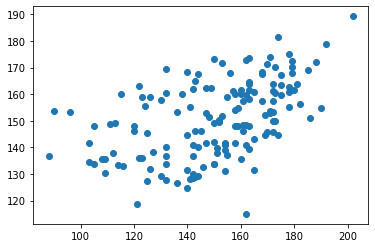

```python
from sklearn.model_selection import train_test_split
from sklearn.linear_model import LinearRegression
from sklearn.metrics import mean_absolute_error, mean_squared_error
X_train, X_test, Y_train, Y_test = train_test_split(X, Y, test_size = 0.5, random_state = 775)
regressor = LinearRegression()
regressor.fit(X_train, Y_train)
feature_names=X.columns
model_coefficient= regressor.coef_
coefficients_dataframe=pd.DataFrame(data=model_coefficient,index=feature_names,columns=["coefficient value"])
Y_pred = regressor.predict(X_test)
df_preds = pd.DataFrame({'Actual': Y_test.squeeze(), 'Predicted': Y_pred.squeeze()})
mae = mean_absolute_error(Y_test, Y_pred)
mse = mean_squared_error(Y_test, Y_pred)
rmse = np.sqrt(mse)
pred_diff = Y_test - Y_pred




print(X_train)
print(Y_train)
print(regressor.intercept_)
print(regressor.coef_)
print(coefficients_dataframe)
print(df_preds)
print(f'the mean absolute error is: {mae}')
print(f'the mean square error is:  {mse}')
print(f'root mean square error is: {rmse}')
print(f'the mean of the sum of residuals is :{np.mean(pred_diff)}')
plt.scatter(Y_test,Y_pred)
```

```python
## FOR PARTITION 75:25
```

```
     Age  Sex  RestBP  Chol  Fbs  RestECG  ExAng  Oldpeak  Slope   Ca
108   61    1     120   260    0        0      1      3.6      2  1.0
10    57    1     140   192    0        0      0      0.4      2  0.0
138   35    1     120   198    0        0      1      1.6      2  0.0
46    51    1     110   175    0        0      0      0.6      1  0.0
147   41    1     112   250    0        0      0      0.0      1  0.0
..   ...  ...     ...   ...  ...      ...    ...      ...    ...  ...
15    57    1     150   168    0        0      0      1.6      1  0.0
128   44    1     120   220    0        0      0      0.0      1  0.0
85    44    1     140   235    0        2      0      0.0      1  0.0
79    58    1     150   270    0        2      1      0.8      1  0.0
71    67    1     125   254    1        0      0      0.2      2  2.0

[224 rows x 10 columns]
108    140
10     148
138    130
46     123
147    179
      ...
15     174
128    170
85     180
79     111
71     163
Name: MaxHR, Length: 224, dtype: int64
the regressor estimate is: 191.7537894872004
the coefficients are :[ -1.0200047    0.73158199   0.16610838   0.03188599   1.37582894
   1.04634852 -13.04603709  -1.45323977  -7.08838434  -2.04483985]
         coefficient value
Age              -1.020005
Sex               0.731582
RestBP            0.166108
Chol              0.031886
Fbs               1.375829
RestECG           1.046349
ExAng           -13.046037
Oldpeak          -1.453240
Slope            -7.088384
Ca               -2.044840
     Actual   Predicted
159     151  140.971795
26      172  156.279374
50      168  164.555178
235     116  132.919577
258     143  149.814329
..      ...         ...
44      169  156.654281
168     156  168.664987
69      147  158.438644
272     120  144.808554
229     132  130.297141

[75 rows x 2 columns]
the mean absolute error is: 14.516623444401795
the mean square error is:  331.94451973618976
root mean square error is: 18.21934465715465
the mean of the sum of residuals is :1.6559584594559873
```

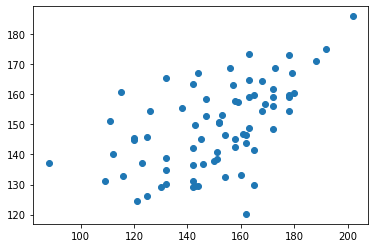

```python
X_train, X_test, Y_train, Y_test = train_test_split(X, Y, test_size = 0.25, random_state = 775)
regressor.fit(X_train, Y_train)
model_coefficient2= regressor.coef_
coefficients_dataframe2=pd.DataFrame(data=model_coefficient2,index=feature_names,columns=["coefficient value"])
Y_pred2= regressor.predict(X_test)
df_preds2 = pd.DataFrame({'Actual': Y_test.squeeze(), 'Predicted': Y_pred2.squeeze()})
mae2 = mean_absolute_error(Y_test, Y_pred2)
mse2 = mean_squared_error(Y_test, Y_pred2)
rmse2 = np.sqrt(mse2)
pred_diff2 = Y_test - Y_pred2


print(X_train)
print(Y_train)
print(f'the regressor estimate is: {regressor.intercept_}')
print(f'the coefficients are :{regressor.coef_}')
print(coefficients_dataframe2)
print(df_preds2)

print(f'the mean absolute error is: {mae2}')
print(f'the mean square error is:  {mse2}')
print(f'root mean square error is: {rmse2}')
print(f'the mean of the sum of residuals is :{np.mean(pred_diff2)}')
plt.scatter(Y_test,Y_pred2)
```

```python
## FOR PARTITION 90:10
```

```
     Age  Sex  RestBP  Chol  Fbs  RestECG  ExAng  Oldpeak  Slope   Ca
201   64    0     180   325    0        0      1      0.0      1  0.0
217   46    0     138   243    0        2      1      0.0      2  0.0
78    48    1     130   245    0        2      0      0.2      2  0.0
87    53    0     128   216    0        2      0      0.0      1  0.0
197   45    0     138   236    0        2      1      0.2      2  0.0
..   ...  ...     ...   ...  ...      ...    ...      ...    ...  ...
15    57    1     150   168    0        0      0      1.6      1  0.0
128   44    1     120   220    0        0      0      0.0      1  0.0
85    44    1     140   235    0        2      0      0.0      1  0.0
79    58    1     150   270    0        2      1      0.8      1  0.0
71    67    1     125   254    1        0      0      0.2      2  2.0

[269 rows x 10 columns]
201    154
217    152
78     180
87     115
197    152
      ...
15     174
128    170
85     180
79     111
71     163
Name: MaxHR, Length: 269, dtype: int64
the regressor estimate is: 187.82431467916635
the coefficients are :[ -0.90526564  -0.06397664   0.14707663   0.03799688   2.69059888
   0.28620419 -12.49392371  -1.75747342  -7.25481361  -2.08235693]
         coefficient value
Age              -0.905266
Sex              -0.063977
RestBP            0.147077
Chol              0.037997
Fbs               2.690599
RestECG           0.286204
ExAng           -12.493924
Oldpeak          -1.757473
Slope            -7.254814
Ca               -2.082357
```

[output cut: 20 more lines]

```
242     163  165.552607
73      158  142.618123
181     150  138.443374
41      178  157.492619
13      173  168.316211
293     144  128.053811
288     163  157.900329
215     162  144.771637
281     179  166.691211
227     172  150.715129
264     125  124.302787
the mean absolute error is: 12.580489256201501
the mean square error is:  261.81182064550654
root mean square error is: 16.180600132427305
the mean of the sum of residuals is :6.146172987087082
```

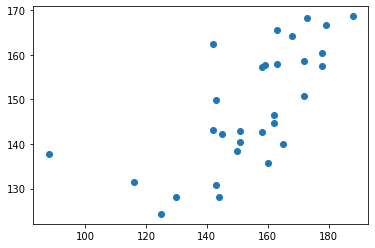

```python
X_train, X_test, Y_train, Y_test = train_test_split(X, Y, test_size = 0.10, random_state = 775)
regressor.fit(X_train, Y_train)
model_coefficient3= regressor.coef_
coefficients_dataframe3=pd.DataFrame(data=model_coefficient3,index=feature_names,columns=["coefficient value"])
Y_pred3= regressor.predict(X_test)
df_preds3 = pd.DataFrame({'Actual': Y_test.squeeze(), 'Predicted': Y_pred3.squeeze()})
mae3 = mean_absolute_error(Y_test, Y_pred3)
mse3 = mean_squared_error(Y_test, Y_pred3)
rmse3 = np.sqrt(mse3)
pred_diff3 = Y_test - Y_pred3


print(X_train)
print(Y_train)
print(f'the regressor estimate is: {regressor.intercept_}')
print(f'the coefficients are :{regressor.coef_}')
print(coefficients_dataframe3)
print(df_preds3)

print(f'the mean absolute error is: {mae3}')
print(f'the mean square error is:  {mse3}')
print(f'root mean square error is: {rmse3}')
print(f'the mean of the sum of residuals is :{np.mean(pred_diff3)}')
plt.scatter(Y_test,Y_pred3)
```

```python
data={'ratio':['50:50','75:25','90:10'],'MAE':[16.020112230550723,14.516623444401795,12.580489256201501],'MSE':[408.13353958413904,331.94451973618976,261.81182064550654],'RMSE':[20.20231520356365,18.21934465715465,16.180600132427305]}
errors=pd.DataFrame(data)
print(errors)
```

```
   ratio        MAE         MSE       RMSE
0  50:50  16.020112  408.133540  20.202315
1  75:25  14.516623  331.944520  18.219345
2  90:10  12.580489  261.811821  16.180600
```

Mean squared error (MSE) measures the amount of error in statistical models. It assesses the average squared difference between the observed and predicted values. When a model has no error, the MSE equals zero. As model error increases, its value increases. A model with less error produces more precise predictions. Only a perfect model with no error produces an MSE of zero. And that doesn’t occur in practice.

Placing emphasis on the mean square errors(MSE) on the three ratio cases, i realize that the MSE at ratio 90:10 is closer to zero compared to the others which in turn produces more precise predictions.